```python
import numpy as np
import scipy as sp

from numpy.linalg import norm

import matplotlib.pyplot as plt

c = lambda *x: np.array([*x])
```

# ADDLIN. HW1, додаткові завдання

Михайло Корешков

## Завдання 1.

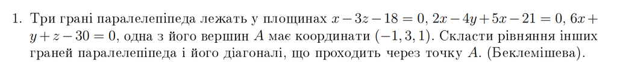

```python
s1 = c(1,0,-3,-18)
s2 = c(2,-4,5,-21)
s3 = c(6,1,1,-30)
A = c(-1,3,1)

def F(side, x): return (side[:3] * x).sum() + side[3]
```

Знайдемо в яких площинах лежить точка A

```python
F(s1,A), F(s2,A), F(s3,A)
```

```
(-22, -30, -32)
```

Бачимо, що точка не задовільняє жодному рівнянню. Значить лежить в інших трьох площинах

З рівнянь площин ми знаємо їх нормальні вектори. Вони всі направлені в один бік відносно тіла (назовні чи всередину), бо всі значення фукнціоналів на точці А мають один знак.

Спочатку знайду точку перетину трьох площин  
$\vec{n_1} \cdot \vec x + d_1 = 0$  
$\vec{n_2} \cdot \vec x + d_2 = 0$  
$\vec{n_3} \cdot \vec x + d_3 = 0$  
Або  
$(n_{ij}) \cdot x = -\vec d$  
Тобто  
$x = -N^{-1}\vec d$, де $N = (n_{ij})$ - матриця нормальних векторів записаних у рядки

```python
N = c(s1,s2,s3)[:,:3]
d = c(s1,s2,s3)[:,-1]

Ninv = np.linalg.inv(N)

A1 = -Ninv @ d

A1, F(s1,A1), F(s2,A1), F(s3,A1)
```

```
(array([ 6.72413793, -6.5862069 , -3.75862069]),
 0.0,
 0.0,
 7.105427357601002e-15)
```

Знайшли точку перетину трьох даних площин, назвали її А1. Також перевірили, що вона дійсно задовільняє всім трьом рівнянням площин.

Далі шукаємо вектор діагоналі А1-А

```python
A1A = A-A1
A1A
```

```
array([-7.72413793,  9.5862069 ,  4.75862069])
```

Далі знаходимо вектори ребер, що починаються в А1. Всі ці вектори будуть колінеарні відповідним нормальним векторам площин. Можемо обчислити їх довжини за допомогою скалярного добутку діагоналі з нормальним вектором.

```python
A1A @ s1[:3]
```

```
-22.0
```

Тобто нормалі направлені назовні

Обчислимо координати діагоналі у системі координат, побудованій на ребрах паралелепіпеда

```python
# backwards transform
B = N.T
# forward transform
F = Ninv.T # = np.linalg.inv(B)

X1 = F @ A1A
X1
```

```
array([-5.30638129, -2.30519223,  0.36543797])
```

Обчислимо відповідні векторні компоненти. Тобто три вектори, кожен з яких паралельний одному з нормальних векторів сторін, і які в сумі дають діагональ.

```python
v1 = X1[0] * N[0]
v2 = X1[1] * N[1]
v3 = X1[2] * N[2]

v1,v2,v3
```

```
(array([-5.30638129, -0.        , 15.91914388]),
 array([ -4.61038446,   9.22076893, -11.52596116]),
 array([2.19262782, 0.36543797, 0.36543797]))
```

Також перевіримо, що їх сума дійсно дорівнюватиме діагоналі

```python
norm(v1+v2+v3-A1A)
```

```
2.6645352591003757e-15
```

```python
%matplotlib widget
```

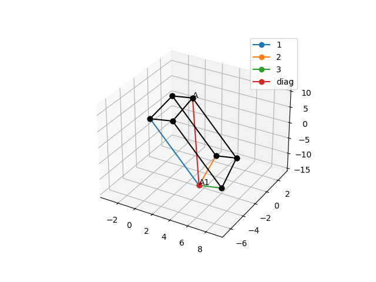

```python
plt.close()
ax = plt.figure().add_subplot(projection='3d')

def pline(ax,a,b, *ar, **kar):
    x = c(a,b).T
    ax.plot(*x, '-o', *ar, **kar)

pline(ax, A1, A1+v1, label='1')
pline(ax, A1, A1+v2, label='2')
pline(ax, A1, A1+v3, label='3')
pline(ax, A1, A, label='diag')

pline(ax, A1+v1, A1+v1+v2, c='k')
pline(ax, A1+v1, A1+v1+v3, c='k')
pline(ax, A1+v2, A1+v2+v1, c='k')
pline(ax, A1+v2, A1+v2+v3, c='k')
pline(ax, A1+v3, A1+v3+v2, c='k')
pline(ax, A1+v3, A1+v3+v1, c='k')

pline(ax, A1+v1+v2, A1+v1+v2+v3, c='k')
pline(ax, A1+v1+v3, A1+v1+v2+v3, c='k')
pline(ax, A1+v2+v3, A1+v1+v2+v3, c='k')

# normal vectors

# z3 = np.zeros(3)
# pline(ax, z3, N[0], label='n1')
# pline(ax, z3, N[1], label='n2')
# pline(ax, z3, N[2], label='n3')

ax.text(*A1, 'A1')
ax.text(*A, 'A')

plt.legend()
# ax.set_aspect('equal')
```

## Задача 2

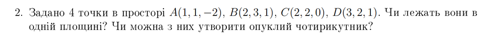

```python
A = c(1,1,-2)
B = c(2,3,1)
C = c(2,2,0)
D = c(3,2,1)
```

Перевіримо чи лежать в одній площині. Якщо лежать, то ранг матриці, утворений координатами векторів $AB, AC, AD$, дорівнюватиме 2

```python
np.linalg.matrix_rank(c(B-A, C-A, D-A))
```

```
2
```

Отже, дійсно лежать в одній площині. Зобразимо фігуру

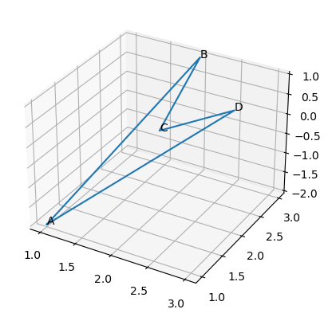

```python
%matplotlib inline
ax = plt.figure().add_subplot(projection='3d')
ax.plot(*(c(A,B,C,D,A).T))
ax.text(*A, 'A')
ax.text(*B, 'B')
ax.text(*C, 'C')
ax.text(*D, 'D')
```

Для перевірки опуклості достатньо обчислити проекції всіх вершин на всі сторони, яким вони не належать. Якщо всі точки проектуються всередину - фігура опукла. Інакше - неопукла.

```python
def check(origin, side_point, check_point):
    # print(check_point-origin, side_point-origin, (check_point-origin)@(side_point-origin), norm(side_point-origin)**2, (check_point-origin)@(side_point-origin) / norm(side_point-origin)**2)
    return (check_point-origin)@(side_point-origin) / norm(side_point-origin)**2

(check(A, B, C),
check(A, B, D),
check(B, C, A),
check(B, C, D),
check(C, D, A),
check(C, D, B),
check(D, A, B),
check(D, A, C))
```

```
(0.6428571428571429,
 0.9285714285714286,
 2.4999999999999996,
 0.4999999999999999,
 -1.4999999999999998,
 0.4999999999999999,
 0.07142857142857142,
 0.35714285714285715)
```

бачимо значення менше нуля та більше одиниці, тобто проекції поза сторонами. Значить, фігура неопукла

## Завдання 3

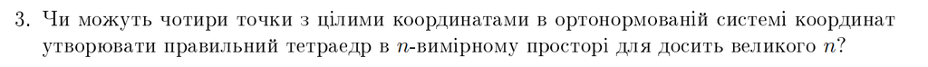

Я надам приклад тетраедеру в 4вимірному просторі. $$ A(1,0,0,0)\\ B(0,1,0,0)\\ C(0,0,1,0)\\ D(0,0,0,1)\\ \\ |AB|=|AC|=|AD|=|BC|=|BD|=|CD|=\sqrt 2 $$

Для більших розмірностей можна побудувати цей самий тетраедр залишаючи інші координати нульовими

## Завдання 5

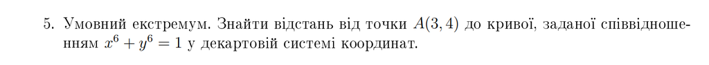

Відстань буде мінімальною в тій точці, де дотична до кривої буде перпендикулярна вектору від точки до кривої. $$F(x,y) = x^6+y^6-1$$ $$F'_x(x,y) = 6x^5$$ $$F'_y(x,y) = 6y^5$$ $$\nabla F = (6x^5, 6y^5)$$ $$v = (x-3, y-4)$$ $$\nabla F \cdot v = 6x^6-18x^5+6y^6-24y^5=0$$ $$x^6+y^6-3x^5-4y^5=0$$ Зверну увагу, що можна зменшити область пошуку розв'язків до $x,y>0$

$$3x^5+4y^5=x^6+y^6=1$$

```python
3**6 + 4**6
```

```
4825
```

Не поки що далі